# Welcome to R-Ladies St. Louis

R You Triggered? Using R to Find Words That Sink Grants

2025-09-10

# Materials for today

Materials for today can be found at https://github.com/coding2share/trigger-words

To follow along today you will need the following things:

- RStudio and R
- Packages: dplyr, DT, officer, openxlsx2, shiny, shinydashboard, stringr, tools

# What is R-Ladies?

- R-Ladies is a world-wide organization with the mission of promoting **gender diversity in the R community**
- Started in San Francisco in 2012 and now has **225 chapters** globally (check out [rladies.org](https://rladies.org/) for more information)
- R-Ladies is rebranding to `R-Ladies+` in order to be more inclusive of all underrepresented genders in the R community. You can read more about this transition [here](https://rladies.org/news/rebranding-rladies/).

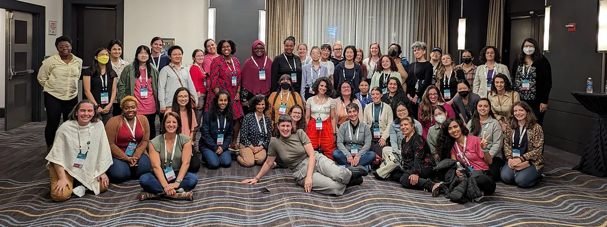

# R-Ladies St. Louis

Started in September 2017 by Jenine Harris and Chelsea West

Co-organizers for **`2025-26`** include:

- Jenine Harris (Washington University)
- Mary Painter (University of Colorado, Boulder)
- Shelly Cooper (Washington University)
- Crystal Lewis (Freelance Data Management Consultant)
- Laura Rose (Hinge Health)

# 2025-26 Schedule

- Sept 10, 2025: R You Triggered? Using R to Find Words That Sink Grants (Bobbi Carothers)
- Oct 29, 2025 6pm CDT: Automate File Management in R with the {fs} Package (Jadey Ryan)
- the rest is TBD…

# Announcements

- We will be recording this talk
  - Feel free to turn off your cameras if you do not want to be recorded
- Use the chat to ask questions (to everyone **or** directly to the host)

Code of Conduct  
https://rladies.org/coc/

# Want to learn more or get involved?

Visit **rladies.org** to learn about the mission and global work of R-Ladies

- Email us at rladiesstl@gmail.com
- Follow us on LinkedIn [@r-ladies-st-louis](https://www.linkedin.com/company/r-ladies-st-louis/)
- RSVP for future talks on [Meetup](https://www.meetup.com/R-Ladies-St-Louis/)
- Check out past recorded talks on our [YouTube Channel](https://www.youtube.com/channel/UCQ7DcXWJm3es06U7lGmBDkw/featured)
- Join our Slack Workspace https://tinyurl.com/5dmjxamn
- Follow us on [Bluesky](https://bsky.app/profile/r-ladies-stl.bsky.social)

# About today’s speaker

- Bobbi Carothers is a senior data analyst at the WashU School of Public Health.
- She was one of the R experts at the very first R-Ladies St. Louis Meetup in 2017.
- Her work includes development of online survey tools, analysis, as well as report and paper development.
- Prior projects have included evaluations for the local, regional, state, and national health organizations.